# Questioning the influence of roots: A soil fauna perspective on rhizosphere space

## Setup and data preparation

## 1. The rhizosphere effect: attraction and spatial signature

> To quantify habitat selection, we overlaid invertebrate occurrence data onto high-resolution root distance maps, calculating the distance from each individual’s centroid detection to the nearest root. We interpreted these distances within a Resource Selection Function (RSF) framework (Calenge *et al.* 2005). To characterize habitat availability, we projected 50 random points onto the corresponding root distance map for every invertebrate occurrence. We then derived the standardized marginality index (Z-score) by calculating the deviation of the observed distance from the mean null expected distance, scaled by the expected standard deviation. This index serves as a measure of spatial marginality: **negative values indicate active biological selection (attraction) of the rhizosphere, whereas positive values signify avoidance relative to a random spatial distribution**.

### *Do soil fauna actively select the rhizosphere space ?*

The central hypothesis of this study, which concerns the influence of roots on the spatial distribution of soil invertebrates, was first examined by testing for departures from random root-associated habitat use. Normalized marginality values were tested against zero using Wilcoxon signed-rank tests. Given the hypothesized functional specificities of organisms and root traits, these tests were conducted independently for each invertebrate taxon and root functional category.

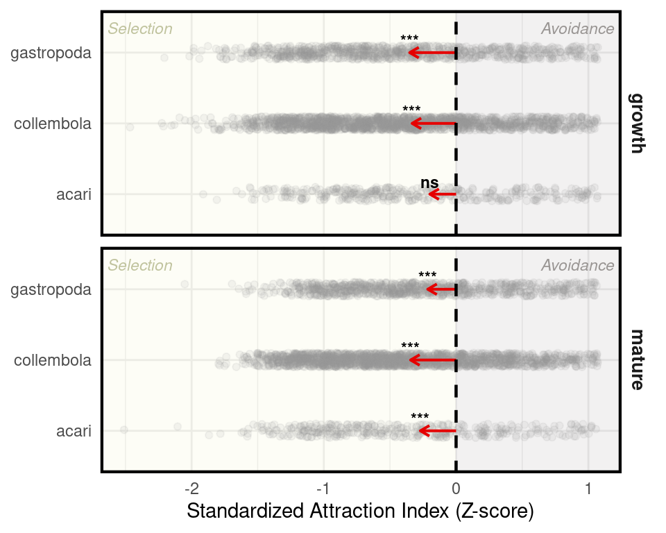

(a) Negative Z-scores indicate active selection of the root zone

Figure 1: Rhizosphere Attraction Index

The Figure 1 reveals **significant, taxa-specific attraction to the root surface**, particularly for Collembola and Gastropoda. The strength of this selection varies by root type, suggesting that biological drivers - such as root exudation - shape spatial clustering beyond what is expected by chance.

## 2. The geometric niche: habitat availability constraint

### *Are fauna close to the root by choice (attraction) or necessity (habitat saturation) ?*

While attraction is a key driver, the physical presence of roots inherently constrains the available habitat. As surface root density increases, bulk soil volume diminishes, mathematically increasing the probability of fauna-root encounters regardless of biological preference. To isolate the true “biological signal,” we modeled the $z$-score across a surface root density gradient. We utilized a Generalized Additive Model (GAM) with a Student-t (scat) distribution to account for the heavy-tailed nature of ecological distance data.

Smooth term results for surface root density (root_cm2_count) on z_score by root type and taxon

| Taxa | Root Type | Complexity (EDF) | Ref.df | Chi-square | p-value | Sign. |
| --- | --- | --- | --- | --- | --- | --- |
| acari | growth | 1.000 | 1.000 | 1.418 | 0.234 | ns |
|  | mature | 1.000 | 1.000 | 0.550 | 0.458 | ns |
| collembola | growth | 1.432 | 1.732 | 1.451 | 0.538 | ns |
|  | mature | 1.000 | 1.000 | 0.068 | 0.795 | ns |
| gastropoda | growth | 1.000 | 1.000 | 0.455 | 0.500 | ns |
|  | mature | 1.000 | 1.000 | 0.650 | 0.420 | ns |

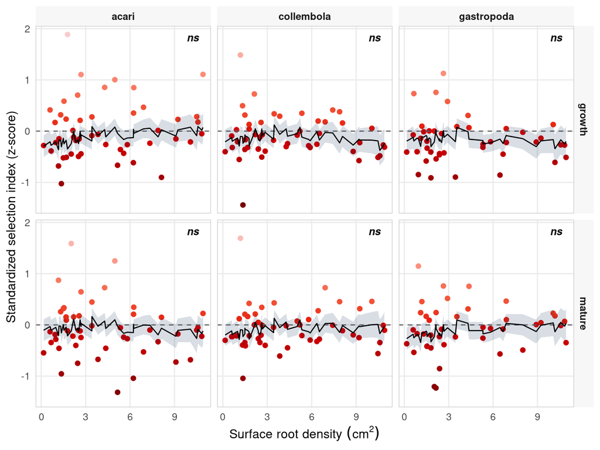

(a) Negative values represent active biological attraction beyond spatial probability

Figure 2: Biological selection vs. geometric constraint

## 3. The selection - demography link : trait or by-product ?

### *Is root selection a mechanical consequence of high population density or a functional driver of invertebrate success ?*

We tested two competing hypotheses to explain the relationship between spatial behavior and population dynamics: a density-driven approach, which tests whether demographic processes dictate spatial behavior, and a performance-based approach, which tests whether the ability to locate and exploit roots leads to population growth.

#### **1. Density-driven hypothesis: Do demographic processes dictate spatial behaviour?**

*“The intensity of root selection is a behavioural response constrained by population density (density dependence).”*

```r
density_driven_model <- gam(delta.resid ~ Predicted.class.levelup + root_type + s(abundance, by =interaction(Predicted.class.levelup, root_type, drop=TRUE), k=10) + s(scanner, bs="re")+ s(period, bs="re"), family = gaussian(link = "identity"),  method = "REML", select = TRUE, data = habitat_delta)
```

#### **2. Performance-based approach : Does an organism’s ability to locate and exploit the root result in an increase in its population?**

*As an “oasis” of resources (exudates, associated microflora, moisture), the root is not just a place where they happen to be, but a driver of their population dynamics. If a taxon is able to effectively ‘select’ roots (for mucus, exudates or microhabitats), it gains access to more energy, which promotes its reproduction and therefore its overall abundance.*

```r
performance_based_model <- gam(abundance ~ Predicted.class.levelup + root_type + s(delta.resid, by = interaction(Predicted.class.levelup, root_type, drop = TRUE), k=5) + s(scanner, bs="re")+ s(period, bs="re"), Gamma(link = "log"), method = "REML", select = TRUE, data = habitat_delta)
```

#### Models results comparison

To isolate biological signals from environmental noise, we partitioned the model deviance ($D^2$) into marginal $D^2$ (fixed biological predictors) and random $D^2$ (stochastic variation from scanner and period). We prioritized $D^2$ over traditional $R^2$ as it provides a robust, likelihood-based measure of fit for non-Gaussian Generalized Additive Models (GAMs).

Table 1: Performance and Deviance Partitioning of Competing Hypotheses

| Hypothesis | Family | Deviance Partitioning (D²) Total D² | Deviance Partitioning (D²) Marginal D² | Deviance Partitioning (D²) Random D² | Fit Statistics Adj. R² | Fit Statistics AIC |
| --- | --- | --- | --- | --- | --- | --- |
| Density-driven | gaussian | 0.7% | 0.5% | 0.2% | -0.006 | 894.053 |
| Performance-based | Gamma | 41.7% | 9.5% | 32.1% | 0.276 | 364.796 |

#### Performance-based drivers of invertebrate success

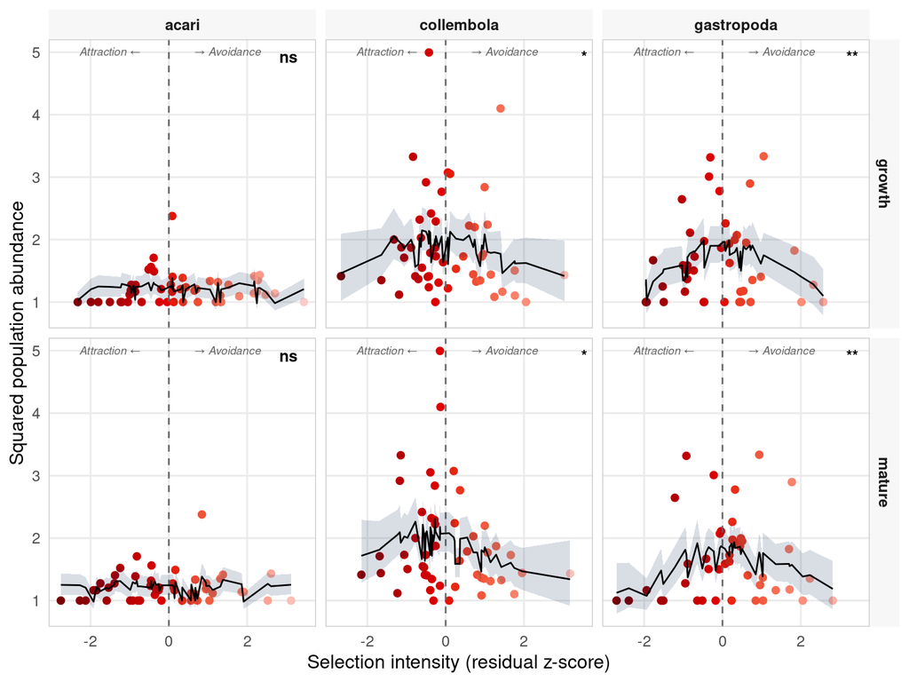

Figure 3: Demographic response to root selection intensity